# Convolutional Neural Networks

## Project: Write an Algorithm for a Dog Identification App

In this notebook, some template code has already been provided for you, and you will need to implement additional functionality to successfully complete this project. You will not need to modify the included code beyond what is requested. Sections that begin with **'(IMPLEMENTATION)'** in the header indicate that the following block of code will require additional functionality which you must provide. Instructions will be provided for each section, and the specifics of the implementation are marked in the code block with a 'TODO' statement. Please be sure to read the instructions carefully!

> **Note**: Once you have completed all of the code implementations, you need to finalize your work by exporting the Jupyter Notebook as an HTML document. Before exporting the notebook to html, all of the code cells need to have been run so that reviewers can see the final implementation and output. You can then export the notebook by using the menu above and navigating to **File -> Download as -> HTML (.html)**. Include the finished document along with this notebook as your submission.

In addition to implementing code, there will be questions that you must answer which relate to the project and your implementation. Each section where you will answer a question is preceded by a **'Question X'** header. Carefully read each question and provide thorough answers in the following text boxes that begin with **'Answer:'**. Your project submission will be evaluated based on your answers to each of the questions and the implementation you provide.

> **Note:** Code and Markdown cells can be executed using the **Shift + Enter** keyboard shortcut. Markdown cells can be edited by double-clicking the cell to enter edit mode.

The rubric contains *optional* "Stand Out Suggestions" for enhancing the project beyond the minimum requirements. If you decide to pursue the "Stand Out Suggestions", you should include the code in this Jupyter notebook.

### Why We're Here

In this notebook, you will make the first steps towards developing an algorithm that could be used as part of a mobile or web app. At the end of this project, your code will accept any user-supplied image as input. If a dog is detected in the image, it will provide an estimate of the dog's breed. If a human is detected, it will provide an estimate of the dog breed that is most resembling. The image below displays potential sample output of your finished project (... but we expect that each student's algorithm will behave differently!).

[figure not shown]

In this real-world setting, you will need to piece together a series of models to perform different tasks; for instance, the algorithm that detects humans in an image will be different from the CNN that infers dog breed. There are many points of possible failure, and no perfect algorithm exists. Your imperfect solution will nonetheless create a fun user experience!

### The Road Ahead

We break the notebook into separate steps. Feel free to use the links below to navigate the notebook.

- Step 0: Import Datasets
- Step 1: Detect Humans
- Step 2: Detect Dogs
- Step 3: Create a CNN to Classify Dog Breeds (from Scratch)
- Step 4: Create a CNN to Classify Dog Breeds (using Transfer Learning)
- Step 5: Write your Algorithm
- Step 6: Test Your Algorithm

## Step 0: Import Datasets

Make sure that you've downloaded the required human and dog datasets:

**Note: if you are using the Udacity workspace, you *DO NOT* need to re-download these - they can be found in the `/data` folder as noted in the cell below.**

- Download the [dog dataset](https://s3-us-west-1.amazonaws.com/udacity-aind/dog-project/dogImages.zip). Unzip the folder and place it in this project's home directory, at the location `/dog_images`.
- Download the [human dataset](https://s3-us-west-1.amazonaws.com/udacity-aind/dog-project/lfw.zip). Unzip the folder and place it in the home directory, at location `/lfw`.

*Note: If you are using a Windows machine, you are encouraged to use [7zip](http://www.7-zip.org/) to extract the folder.*

In the code cell below, we save the file paths for both the human (LFW) dataset and dog dataset in the numpy arrays `human_files` and `dog_files`.

```python
import numpy as np
from glob import glob

# load filenames for human and dog images
human_files = np.array(glob("/data/lfw/*/*"))
dog_files = np.array(glob("/data/dog_images/*/*/*"))

# print number of images in each dataset
print('There are %d total human images.' % len(human_files))
print('There are %d total dog images.' % len(dog_files))
```

```
There are 13233 total human images.
There are 8351 total dog images.
```

## Step 1: Detect Humans

In this section, we use OpenCV's implementation of [Haar feature-based cascade classifiers](http://docs.opencv.org/trunk/d7/d8b/tutorial_py_face_detection.html) to detect human faces in images.

OpenCV provides many pre-trained face detectors, stored as XML files on [github](https://github.com/opencv/opencv/tree/master/data/haarcascades). We have downloaded one of these detectors and stored it in the `haarcascades` directory. In the next code cell, we demonstrate how to use this detector to find human faces in a sample image.

```
Number of faces detected: 1
```

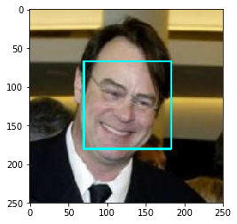

```python
import cv2
import matplotlib.pyplot as plt
%matplotlib inline


def show_face(img_path, scale=None):
    # extract pre-trained face detector
    face_cascade = cv2.CascadeClassifier('haarcascades/haarcascade_frontalface_alt.xml')

    # load color (BGR) image
    img = cv2.imread(img_path)

    # resize
    if scale:
        width = int(img.shape[1] * scale)
        height = int(img.shape[0] * scale)
        img = cv2.resize(img, (width, height), interpolation = cv2.INTER_AREA)

    # convert BGR image to grayscale
    gray = cv2.cvtColor(img, cv2.COLOR_BGR2GRAY)

    # find faces in image
    faces = face_cascade.detectMultiScale(gray)

    # print number of faces detected in the image
    print('Number of faces detected:', len(faces))

    # get bounding box for each detected face
    for (x,y,w,h) in faces:
        # add bounding box to color image
        cv2.rectangle(img,(x,y),(x+w,y+h),(255,255,0),2)

    # convert BGR image to RGB for plotting
    cv_rgb = cv2.cvtColor(img, cv2.COLOR_BGR2RGB)

    # display the image, along with bounding box
    plt.imshow(cv_rgb)
    plt.show()

show_face(human_files[0])
```

Before using any of the face detectors, it is standard procedure to convert the images to grayscale. The `detectMultiScale` function executes the classifier stored in `face_cascade` and takes the grayscale image as a parameter.

In the above code, `faces` is a numpy array of detected faces, where each row corresponds to a detected face. Each detected face is a 1D array with four entries that specifies the bounding box of the detected face. The first two entries in the array (extracted in the above code as `x` and `y`) specify the horizontal and vertical positions of the top left corner of the bounding box. The last two entries in the array (extracted here as `w` and `h`) specify the width and height of the box.

### Write a Human Face Detector

We can use this procedure to write a function that returns `True` if a human face is detected in an image and `False` otherwise. This function, aptly named `face_detector`, takes a string-valued file path to an image as input and appears in the code block below.

```python
# returns "True" if face is detected in image stored at img_path
def face_detector(img_path):
    face_cascade = cv2.CascadeClassifier('haarcascades/haarcascade_frontalface_alt.xml')
    img = cv2.imread(img_path)
    gray = cv2.cvtColor(img, cv2.COLOR_BGR2GRAY)
    faces = face_cascade.detectMultiScale(gray)
    return len(faces) > 0
```

### (IMPLEMENTATION) Assess the Human Face Detector

**Question 1:** Use the code cell below to test the performance of the `face_detector` function.

- What percentage of the first 100 images in `human_files` have a detected human face?
- What percentage of the first 100 images in `dog_files` have a detected human face?

Ideally, we would like 100% of human images with a detected face and 0% of dog images with a detected face. You will see that our algorithm falls short of this goal, but still gives acceptable performance. We extract the file paths for the first 100 images from each of the datasets and store them in the numpy arrays `human_files_short` and `dog_files_short`.

**Answer:** (You can print out your results and/or write your percentages in this cell)

```python
from tqdm import tqdm

human_files_short = human_files[:100]
dog_files_short = dog_files[:100]

#-#-# Do NOT modify the code above this line. #-#-#

cv_human_accuracy = np.mean([face_detector(f) for f in human_files_short])
cv_dog_accuracy = np.mean([face_detector(f) for f in dog_files_short])

print(100 * cv_human_accuracy, "% of human files")
print(100 * cv_dog_accuracy, "% of dog files")
```

```
98.0 % of human files
17.0 % of dog files
```

We suggest the face detector from OpenCV as a potential way to detect human images in your algorithm, but you are free to explore other approaches, especially approaches that make use of deep learning :). Please use the code cell below to design and test your own face detection algorithm. If you decide to pursue this *optional* task, report performance on `human_files_short` and `dog_files_short`.

```python
### (Optional)
### TODO: Test performance of anotherface detection algorithm.
### Feel free to use as many code cells as needed.
```

## Step 2: Detect Dogs

In this section, we use a [pre-trained model](http://pytorch.org/docs/master/torchvision/models.html) to detect dogs in images.

### Obtain Pre-trained VGG-16 Model

The code cell below downloads the VGG-16 model, along with weights that have been trained on [ImageNet](http://www.image-net.org/), a very large, very popular dataset used for image classification and other vision tasks. ImageNet contains over 10 million URLs, each linking to an image containing an object from one of [1000 categories](https://gist.github.com/yrevar/942d3a0ac09ec9e5eb3a).

```python
import torch
import torchvision.models as models

# define VGG16 model
VGG16 = models.vgg16(pretrained=True)

# check if CUDA is available
use_cuda = torch.cuda.is_available()

# move model to GPU if CUDA is available
if use_cuda:
    VGG16 = VGG16.cuda()
```

Given an image, this pre-trained VGG-16 model returns a prediction (derived from the 1000 possible categories in ImageNet) for the object that is contained in the image.

### (IMPLEMENTATION) Making Predictions with a Pre-trained Model

In the next code cell, you will write a function that accepts a path to an image (such as `'dogImages/train/001.Affenpinscher/Affenpinscher_00001.jpg'`) as input and returns the index corresponding to the ImageNet class that is predicted by the pre-trained VGG-16 model. The output should always be an integer between 0 and 999, inclusive.

Before writing the function, make sure that you take the time to learn how to appropriately pre-process tensors for pre-trained models in the [PyTorch documentation](http://pytorch.org/docs/stable/torchvision/models.html).

```python
from PIL import Image
import torchvision.transforms as transforms

def VGG16_predict(img_path):
    '''
    Use pre-trained VGG-16 model to obtain index corresponding to
    predicted ImageNet class for image at specified path

    Args:
        img_path: path to an image

    Returns:
        Index corresponding to VGG-16 model's prediction
    '''
    data_transform = transforms.Compose([transforms.Resize(224),
                                         transforms.CenterCrop(224),
                                         transforms.ToTensor(),
                                         transforms.Normalize((0.5, 0.5, 0.5), (0.5, 0.5, 0.5))
                                        ])

    img = Image.open(img_path)
    data = data_transform(img).unsqueeze(0)

    if torch.cuda.is_available():
        data = data.cuda()

    VGG16.eval()
    _, output = torch.max(VGG16(data), 1)

    return output.item() # predicted class index
```

### (IMPLEMENTATION) Write a Dog Detector

While looking at the [dictionary](https://gist.github.com/yrevar/942d3a0ac09ec9e5eb3a), you will notice that the categories corresponding to dogs appear in an uninterrupted sequence and correspond to dictionary keys 151-268, inclusive, to include all categories from `'Chihuahua'` to `'Mexican hairless'`. Thus, in order to check to see if an image is predicted to contain a dog by the pre-trained VGG-16 model, we need only check if the pre-trained model predicts an index between 151 and 268 (inclusive).

Use these ideas to complete the `dog_detector` function below, which returns `True` if a dog is detected in an image (and `False` if not).

```python
def dog_detector(img_path):
    if 151 <= VGG16_predict(img_path) <= 268:
        return True
    else:
        return False
```

### (IMPLEMENTATION) Assess the Dog Detector

**Question 2:** Use the code cell below to test the performance of your `dog_detector` function.

- What percentage of the images in `human_files_short` have a detected dog?
- What percentage of the images in `dog_files_short` have a detected dog?

**Answer:**

```python
vgg16_human_accuracy = np.mean([dog_detector(f) for f in human_files_short])
vgg16_dog_accuracy = np.mean([dog_detector(f) for f in dog_files_short])

print(100 * vgg16_human_accuracy, "% of human files")
print(100 * vgg16_dog_accuracy, "% of dog files")
```

```
0.0 % of human files
100.0 % of dog files
```

We suggest VGG-16 as a potential network to detect dog images in your algorithm, but you are free to explore other pre-trained networks (such as [Inception-v3](http://pytorch.org/docs/master/torchvision/models.html#inception-v3), [ResNet-50](http://pytorch.org/docs/master/torchvision/models.html#id3), etc). Please use the code cell below to test other pre-trained PyTorch models. If you decide to pursue this *optional* task, report performance on `human_files_short` and `dog_files_short`.

```python
# Create generic helper function
def custom_dog_detector(img_path, model, input_size):
    data_transform = transforms.Compose([transforms.Resize(input_size),
                                         transforms.CenterCrop(input_size),
                                         transforms.ToTensor(),
                                         transforms.Normalize((0.5, 0.5, 0.5), (0.5, 0.5, 0.5))
                                        ])
    img = Image.open(img_path)
    data = data_transform(img).unsqueeze(0)
    data = data.cuda() if torch.cuda.is_available() else data.cpu()

    model.eval()
    _, output = torch.max(model(data), 1)

    if 151 <= output.item() <= 268:
        return True
    else:
        return False
```

**Resnet-50**

```python
resnet = models.resnet50(pretrained=True)
resnet = resnet.cuda() if torch.cuda.is_available() else resnet.cpu()

resnet_human_accuracy = np.mean([custom_dog_detector(f, resnet, 224) for f in human_files_short])
resnet_dog_accuracy = np.mean([custom_dog_detector(f, resnet, 224) for f in dog_files_short])

print(100 * resnet_human_accuracy, "% of human files")
print(100 * resnet_dog_accuracy, "% of dog files")
```

```
0.0 % of human files
100.0 % of dog files
```

**Inception V3**

```python
inception = models.inception_v3(pretrained=True)
inception = inception.cuda() if torch.cuda.is_available() else inception.cpu()

inception_human_accuracy = np.mean([custom_dog_detector(f, inception, 299) for f in human_files_short])
inception_dog_accuracy = np.mean([custom_dog_detector(f, inception, 299) for f in dog_files_short])

print(100 * inception_human_accuracy, "% of human files")
print(100 * inception_dog_accuracy, "% of dog files")
```

```
Downloading: "https://download.pytorch.org/models/inception_v3_google-1a9a5a14.pth" to /root/.torch/models/inception_v3_google-1a9a5a14.pth
```

```
1.0 % of human files
100.0 % of dog files
```

## Step 3: Create a CNN to Classify Dog Breeds (from Scratch)

Now that we have functions for detecting humans and dogs in images, we need a way to predict breed from images. In this step, you will create a CNN that classifies dog breeds. You must create your CNN *from scratch* (so, you can't use transfer learning *yet*!), and you must attain a test accuracy of at least 10%. In Step 4 of this notebook, you will have the opportunity to use transfer learning to create a CNN that attains greatly improved accuracy.

We mention that the task of assigning breed to dogs from images is considered exceptionally challenging. To see why, consider that *even a human* would have trouble distinguishing between a Brittany and a Welsh Springer Spaniel.

| Brittany | Welsh Springer Spaniel |
| --- | --- |

It is not difficult to find other dog breed pairs with minimal inter-class variation (for instance, Curly-Coated Retrievers and American Water Spaniels).

| Curly-Coated Retriever | American Water Spaniel |
| --- | --- |

Likewise, recall that labradors come in yellow, chocolate, and black. Your vision-based algorithm will have to conquer this high intra-class variation to determine how to classify all of these different shades as the same breed.

| Yellow Labrador | Chocolate Labrador | Black Labrador |
| --- | --- | --- |

We also mention that random chance presents an exceptionally low bar: setting aside the fact that the classes are slightly imabalanced, a random guess will provide a correct answer roughly 1 in 133 times, which corresponds to an accuracy of less than 1%.

Remember that the practice is far ahead of the theory in deep learning. Experiment with many different architectures, and trust your intuition. And, of course, have fun!

### (IMPLEMENTATION) Specify Data Loaders for the Dog Dataset

Use the code cell below to write three separate [data loaders](http://pytorch.org/docs/stable/data.html#torch.utils.data.DataLoader) for the training, validation, and test datasets of dog images (located at `dog_images/train`, `dog_images/valid`, and `dog_images/test`, respectively). You may find [this documentation on custom datasets](http://pytorch.org/docs/stable/torchvision/datasets.html) to be a useful resource. If you are interested in augmenting your training and/or validation data, check out the wide variety of [transforms](http://pytorch.org/docs/stable/torchvision/transforms.html?highlight=transform)!

```python
from torchvision import datasets
from torch.utils.data import DataLoader
import torchvision.transforms as transforms
from PIL import ImageFile
ImageFile.LOAD_TRUNCATED_IMAGES = True


train_transform = transforms.Compose([
    transforms.RandomResizedCrop(224),
    transforms.RandomHorizontalFlip(p=0.3),
    transforms.RandomRotation(30),
    transforms.ToTensor(),
    transforms.Normalize((0.5, 0.5, 0.5), (0.5, 0.5, 0.5))
])

# No random transformations for validation and test set
normal_transform = transforms.Compose([
    transforms.Resize(224),
    transforms.CenterCrop(224),
    transforms.ToTensor(),
    transforms.Normalize((0.5, 0.5, 0.5), (0.5, 0.5, 0.5))
])

train_data = datasets.ImageFolder("/data/dog_images/train", transform=train_transform)
valid_data = datasets.ImageFolder("/data/dog_images/valid", transform=normal_transform)
test_data = datasets.ImageFolder("/data/dog_images/test", transform=normal_transform)
print(len(train_data), len(valid_data), len(test_data))
```

```
6680 835 836
```

```python
batch_size = 32
num_workers = 0
train_loader = DataLoader(train_data, batch_size=batch_size,
                          num_workers=num_workers, shuffle=True)
valid_loader = DataLoader(train_data, batch_size=batch_size,
                          num_workers=num_workers, shuffle=True)
test_loader = DataLoader(test_data, batch_size=batch_size,
                         num_workers=num_workers, shuffle=False) # shuffle false for testing
loaders_scratch = {
    'train': train_loader,
    'valid': valid_loader,
    'test': test_loader
}
```

**Question 3:** Describe your chosen procedure for preprocessing the data.

- How does your code resize the images (by cropping, stretching, etc)? What size did you pick for the input tensor, and why?
- Did you decide to augment the dataset? If so, how (through translations, flips, rotations, etc)? If not, why not?

**Answer**:

### (IMPLEMENTATION) Model Architecture

Create a CNN to classify dog breed. Use the template in the code cell below.

```python
import torch.nn as nn
import torch.nn.functional as F

# define the CNN architecture
class Net(nn.Module):
    def __init__(self):
        super(Net, self).__init__()

        # go deeper is better
        self.conv1 = nn.Conv2d(in_channels=3, out_channels=32, kernel_size=3, stride=1, padding=1)
        self.conv2 = nn.Conv2d(in_channels=32, out_channels=64, kernel_size=5, stride=1, padding=2)
        self.conv2_bn = nn.BatchNorm2d(64)   #batchnorm to speed up traiing
        self.conv3 = nn.Conv2d(in_channels=64, out_channels=64, kernel_size=3, stride=2, padding=1)
        self.conv3_bn = nn.BatchNorm2d(64)

        self.fc1 = nn.Linear(5184, 1032)
        self.fc2 = nn.Linear(1032, 516)
        self.fc3 = nn.Linear(516, 133)

        self.maxpool = nn.MaxPool2d(2, 2)
        self.maxpool2 = nn.MaxPool2d(3, 3)
        self.dropout = nn.Dropout(0.4) # higher is better

    def forward(self, x):

        x = F.elu(self.conv1(x))
        x = self.maxpool(x)

        x = F.elu(self.conv2_bn(self.conv2(x)))
        x = self.maxpool(x)

        x = F.elu(self.conv3_bn(self.conv3(x)))
        x = self.maxpool2(x)

        # flatten
        x = x.view(x.shape[0], -1)

        x = F.elu(self.fc1(x))
        x = self.dropout(x)

        x = F.elu(self.fc2(x))
        x = self.dropout(x)

        x = self.fc3(x)

        return x
```

```python
# Check final size
count = 0
test_model = Net()
for data, target in valid_loader:
    if count > 0:
        break
    print(test_model(data).shape)
    count = 1
```

```
torch.Size([32, 133])
```

```python
#-#-# You do NOT have to modify the code below this line. #-#-#

# instantiate the CNN
model_scratch = Net()

# move tensors to GPU if CUDA is available
use_cuda = torch.cuda.is_available()
if use_cuda:
    model_scratch.cuda()
```

**Question 4:** Outline the steps you took to get to your final CNN architecture and your reasoning at each step.

**Answer:**

*First Submission*

- **Convolutional layers**: First I tried `out_channels=32` in the first CNN layer, but even after training for ~80 epochs the validation loss was still quite high. Thus, I switched to `out_channels=64` in the first layer. I was also motivated by the previous MNIST autoencoder exercise (where we introduced noise), and figured if I used 64 channels there, in a grayscale image, all the more I should be looking at more channels in a RGB image
  - I also experimented with using a larger `kernel` and `stride` in the second conv layer since there many out_channels in the previous layer
  - I continued to use **maxpooling** on all layers to help reduce dimension sizes too
- **Fully connected layers**: Since there were a lot of nodes coming out of the CNN layers, I went with 3 FC layers to gradually bring the dimensions down. I chose to use `log_softmax` in conjunction with an `NLLLoss` criteria.
  - I used **dropout** on the first 2 layers to prevent overffiting
- **Learning rate**: Initially, I set the `lr=0.01` but I felt that training was going very slowly. Thus, I increased it to `lr=0.05`
- **Epochs**: I set `n_epochs = 100`. However I'm not sure when the model stopped training as the output stopped printing/GPU shut itself down after awhile. I estimate it ended around 60-80 epochs.

```
self.conv1 = nn.Conv2d(in_channels=3, out_channels=64, kernel_size=3, stride=1, padding=1)
self.conv2 = nn.Conv2d(in_channels=64, out_channels=32, kernel_size=5, stride=1, padding=2)
self.conv3 = nn.Conv2d(in_channels=32, out_channels=4, kernel_size=3, stride=1, padding=1)
self.fc1 = nn.Linear(4 * 28 * 28, 1032)
self.fc2 = nn.Linear(1032, 516)
self.fc3 = nn.Linear(516, 133)
self.maxpool = nn.MaxPool2d(2, 2)
self.dropout = nn.Dropout(0.2)
---
x = F.relu(self.conv1(x))
x = self.maxpool(x)
x = F.relu(self.conv2(x))
x = self.maxpool(x)
x = F.relu(self.conv3(x))
x = self.maxpool(x)
x = x.view(x.shape[0], -1)
x = F.relu(self.fc1(x))
x = self.dropout(x)
x = F.relu(self.fc2(x))
x = self.dropout(x)
x = F.log_softmax(self.fc3(x), dim=1)
```

### (IMPLEMENTATION) Specify Loss Function and Optimizer

Use the next code cell to specify a [loss function](http://pytorch.org/docs/stable/nn.html#loss-functions) and [optimizer](http://pytorch.org/docs/stable/optim.html). Save the chosen loss function as `criterion_scratch`, and the optimizer as `optimizer_scratch` below.

```python
import torch.optim as optim

criterion_scratch = nn.CrossEntropyLoss()
optimizer_scratch = optim.SGD(model_scratch.parameters(), lr=0.01)
```

### (IMPLEMENTATION) Train and Validate the Model

Train and validate your model in the code cell below. [Save the final model parameters](http://pytorch.org/docs/master/notes/serialization.html) at filepath `'model_scratch.pt'`.

```python
from utils import active_session
```

```python
def train(n_epochs, loaders, model, optimizer, criterion, use_cuda, save_path):
    """returns trained model"""
    # initialize tracker for minimum validation loss
    valid_loss_min = np.Inf

    for epoch in range(1, n_epochs+1):
        # initialize variables to monitor training and validation loss
        train_loss = 0.0
        valid_loss = 0.0

        ###################
        # train the model #
        ###################
        model.train()
        for batch_idx, (data, target) in enumerate(loaders['train']):
            # move to GPU
            if use_cuda:
                data, target = data.cuda(), target.cuda()
            ## find the loss and update the model parameters accordingly
            ## record the average training loss, using something like
            ## train_loss = train_loss + ((1 / (batch_idx + 1)) * (loss.data - train_loss))
            output = model(data)
            loss = criterion(output, target)
            train_loss = train_loss + ((1 / (batch_idx + 1)) * (loss.data - train_loss))

            optimizer.zero_grad()
            loss.backward()
            optimizer.step()

        ######################
        # validate the model #
        ######################
        model.eval()
        for batch_idx, (data, target) in enumerate(loaders['valid']):
            # move to GPU
            if use_cuda:
                data, target = data.cuda(), target.cuda()
            ## update the average validation loss
            output = model(data)
            loss = criterion(output, target)
            valid_loss = valid_loss + ((1 / (batch_idx + 1)) * (loss.data - valid_loss))

        # print training/validation statistics
        print('Epoch: {} \tTraining Loss: {:.6f} \tValidation Loss: {:.6f}'.format(
            epoch,
            train_loss,
            valid_loss
            ))

        ## TODO: save the model if validation loss has decreased
        if valid_loss < valid_loss_min:
            print('..Validation loss decreased ({:.6f} --> {:.6f}).  Saving model ...'.format(
                valid_loss_min, valid_loss))
            torch.save(model.state_dict(), save_path)
            valid_loss_min = valid_loss

    # return trained model
    return model
```

```python
with active_session():
    # train the model
    model_scratch = train(100, loaders_scratch, model_scratch, optimizer_scratch,
                          criterion_scratch, use_cuda, 'model_scratch/model_scratch_6.pt')
```

Copied printout here

[output not shown]

### (IMPLEMENTATION) Test the Model

Try out your model on the test dataset of dog images. Use the code cell below to calculate and print the test loss and accuracy. Ensure that your test accuracy is greater than 10%.

```python
def test(loaders, model, criterion, use_cuda):

    # monitor test loss and accuracy
    test_loss = 0.
    correct = 0.
    total = 0.

    model.eval()
    for batch_idx, (data, target) in enumerate(loaders['test']):
        # move to GPU
        if use_cuda:
            data, target = data.cuda(), target.cuda()
        # forward pass: compute predicted outputs by passing inputs to the model
        output = model(data)
        # calculate the loss
        loss = criterion(output, target)
        # update average test loss
        test_loss = test_loss + ((1 / (batch_idx + 1)) * (loss.data - test_loss))
        # convert output probabilities to predicted class
        pred = output.data.max(1, keepdim=True)[1]
        # compare predictions to true label
        correct += np.sum(np.squeeze(pred.eq(target.data.view_as(pred))).cpu().numpy())
        total += data.size(0)

    print('Test Loss: {:.6f}\n'.format(test_loss))

    print('\nTest Accuracy: %2d%% (%2d/%2d)' % (
        100. * correct / total, correct, total))
```

```python
# call test function
model_scratch.load_state_dict(torch.load('model_scratch/model_scratch_6.pt'))
test(loaders_scratch, model_scratch, criterion_scratch, use_cuda)
```

```
Test Loss: 3.824723


Test Accuracy: 11% (97/836)
```

## Step 4: Create a CNN to Classify Dog Breeds (using Transfer Learning)

You will now use transfer learning to create a CNN that can identify dog breed from images. Your CNN must attain at least 60% accuracy on the test set.

### (IMPLEMENTATION) Specify Data Loaders for the Dog Dataset

Use the code cell below to write three separate [data loaders](http://pytorch.org/docs/master/data.html#torch.utils.data.DataLoader) for the training, validation, and test datasets of dog images (located at `dogImages/train`, `dogImages/valid`, and `dogImages/test`, respectively).

If you like, **you are welcome to use the same data loaders from the previous step**, when you created a CNN from scratch.

```python
INCEPTION_INPUT_SIZE = 299

train_transform = transforms.Compose([
    transforms.RandomResizedCrop(INCEPTION_INPUT_SIZE),
    transforms.RandomHorizontalFlip(p=0.3),
    transforms.RandomRotation(30),
    transforms.ToTensor(),
    transforms.Normalize((0.5, 0.5, 0.5), (0.5, 0.5, 0.5))
])
normal_transform = transforms.Compose([
    transforms.Resize(INCEPTION_INPUT_SIZE),
    transforms.CenterCrop(INCEPTION_INPUT_SIZE),
    transforms.ToTensor(),
    transforms.Normalize((0.5, 0.5, 0.5), (0.5, 0.5, 0.5))
])

train_data = datasets.ImageFolder("/data/dog_images/train", transform=train_transform)
valid_data = datasets.ImageFolder("/data/dog_images/valid", transform=normal_transform)
test_data = datasets.ImageFolder("/data/dog_images/test", transform=normal_transform)

batch_size = 32
num_workers = 0
train_loader = DataLoader(train_data, batch_size=batch_size,
                          num_workers=num_workers, shuffle=True)
valid_loader = DataLoader(train_data, batch_size=batch_size,
                          num_workers=num_workers, shuffle=True)
test_loader = DataLoader(test_data, batch_size=batch_size,
                         num_workers=num_workers, shuffle=False) # false for test data
loaders_transfer = {
    'train': train_loader,
    'valid': valid_loader,
    'test': test_loader
}
```

### (IMPLEMENTATION) Model Architecture

Use transfer learning to create a CNN to classify dog breed. Use the code cell below, and save your initialized model as the variable `model_transfer`.

```python
import torchvision.models as models
import torch.nn as nn

model_transfer = models.inception_v3(pretrained=True)

num_classes = 133
model_transfer.aux_logits = False # turn off aux output
num_ftrs = model_transfer.fc.in_features
model_transfer.fc = nn.Linear(num_ftrs, num_classes)

model_transfer = model_transfer.cuda() if torch.cuda.is_available() else model_transfer.cpu()
```

```
Downloading: "https://download.pytorch.org/models/inception_v3_google-1a9a5a14.pth" to /root/.torch/models/inception_v3_google-1a9a5a14.pth
```

*From first project submission review: How to freeze all the other layers*

```
for param in model_transfer.parameters():
    param.requires_grad = False

n_inputs = model_transfer.fc.in_features

last_layer = nn.Linear(n_inputs, 133, bias=True)

model_transfer.fc = last_layer

last_layer_parameters = model_transfer.fc.parameters()

for param in last_layer_parameters:
    param.requires_grad = True
```

**Question 5:** Outline the steps you took to get to your final CNN architecture and your reasoning at each step. Describe why you think the architecture is suitable for the current problem.

**Answer:**

*Architecture*

1. Among the pretrained models (VGG16, ResNet, and Inception), I chose **Inception** as it has one of the **better performances with reasonable training time**. Resnet-152 has the best performance, but has 10x the number of parameters to optimize for.
   - See table of comparison at bottom of this article: https://towardsdatascience.com/the-w3h-of-alexnet-vggnet-resnet-and-inception-7baaaecccc96
2. After downloading the Inception model, I changed the number of output nodes to the number of classes, 133. I did not add any extra layers
3. I choose to retrain all the weights of the initial model.
   - (Partly because everytime I tried to freeze the weights of all the other layers and only leave the FC layer, pytorch threw an error saying there were no gradients to optimize)

*Training*

### (IMPLEMENTATION) Specify Loss Function and Optimizer

Use the next code cell to specify a [loss function](http://pytorch.org/docs/master/nn.html#loss-functions) and [optimizer](http://pytorch.org/docs/master/optim.html). Save the chosen loss function as `criterion_transfer`, and the optimizer as `optimizer_transfer` below.

```python
import torch.optim as optim

criterion_transfer = nn.CrossEntropyLoss()
optimizer_transfer = optim.SGD(model_transfer.parameters(), lr=0.05)
```

### (IMPLEMENTATION) Train and Validate the Model

Train and validate your model in the code cell below. [Save the final model parameters](http://pytorch.org/docs/master/notes/serialization.html) at filepath `'model_transfer.pt'`.

```python
n_epochs = 15
```

```python
# train the model
model_transfer = train(n_epochs, loaders_transfer, model_transfer, optimizer_transfer,
                       criterion_transfer, use_cuda,
                       'model_transfer/model_transfer_3.pt')
```

[output not shown]

### (IMPLEMENTATION) Test the Model

Try out your model on the test dataset of dog images. Use the code cell below to calculate and print the test loss and accuracy. Ensure that your test accuracy is greater than 60%.

```python
model_transfer.load_state_dict(torch.load('model_transfer/model_transfer_3.pt'))
test(loaders_transfer, model_transfer, criterion_transfer, use_cuda)
```

```
Test Loss: 0.963894


Test Accuracy: 74% (626/836)
```

### (IMPLEMENTATION) Predict Dog Breed with the Model

Write a function that takes an image path as input and returns the dog breed (`Affenpinscher`, `Afghan hound`, etc) that is predicted by your model.

```python
from PIL import Image

model_transfer.load_state_dict(torch.load('model_transfer/model_transfer_3.pt'))

# list of class names by index, i.e. a name can be accessed like class_names[0]
class_names = [item[4:].replace("_", " ") for item in train_data.classes]

def predict_breed_transfer(img_path, model, top_k = 1):
    data_transform = transforms.Compose([transforms.RandomResizedCrop(299),
                                         transforms.ToTensor()])
    img = Image.open(img_path)
    data = data_transform(img).unsqueeze(0)

    if torch.cuda.is_available():
        data = data.cuda()
        model = model.cuda()
    else:
        data = data.cpu()
        model = model.cpu()

    model.eval()
    output = model(data)

    # Take top k outputs
    probs, preds = torch.topk(output.data, k=top_k, dim=1)
    if torch.cuda.is_available():
        probs = probs.cpu().numpy()[0]
        preds = preds.cpu().numpy()[0]
    else:
        probs, preds = probs.numpy()[0], preds.numpy()[0]
    breeds = [class_names[p] for p in preds]

    return list(probs), breeds
```

```python
predict_breed_transfer(dog_files[0], model_transfer, top_k=2)
```

```
([17.671938, 10.659687], ['Mastiff', 'Bullmastiff'])
```

## Step 5: Write your Algorithm

Write an algorithm that accepts a file path to an image and first determines whether the image contains a human, dog, or neither. Then,

- if a **dog** is detected in the image, return the predicted breed.
- if a **human** is detected in the image, return the resembling dog breed.
- if **neither** is detected in the image, provide output that indicates an error.

You are welcome to write your own functions for detecting humans and dogs in images, but feel free to use the `face_detector` and `human_detector` functions developed above. You are **required** to use your CNN from Step 4 to predict dog breed.

Some sample output for our algorithm is provided below, but feel free to design your own user experience!

[figure not shown]

### (IMPLEMENTATION) Write your Algorithm

```python
def run_app(img_path, detector_model, breed_model, input_size = 299):
    ## handle cases for a human face, dog, and neither
    is_dog = custom_dog_detector(img_path, detector_model, input_size)
    is_human = face_detector(img_path)
    probs, breeds = predict_breed_transfer(img_path, breed_model, top_k = 2)

    plt.figure()
    if is_dog:
        title = "woof woof woof (hello in dogspeak)!!\n"
        if probs[0] > 60:
            title += "you must be a cousin of my friend " + breeds[0] + "\n"
        else:
            title += "i'm a little unsure, but i'd say\n"
            title += str(round(probs[0], 1)) + "% " + breeds[0] + '\n'
            title += str(round(probs[1], 1)) + "% " + breeds[1]
    elif is_human:
        title = "darn humans trying to trick the system...\ni'll read ur face anyway....\n"
        if probs[0] > 60:
            title += "you look like a " + breeds[0] + "\n"
        else:
            title += "i'm a little unsure, but i'd say\n"
            title += str(round(probs[0], 1)) + "% " + breeds[0] + '\n'
            title += str(round(probs[1], 1)) + "% " + breeds[1]
    else:
        title = "ERROR - neither human nor dog... are u a cat?!"

    plt.imshow(Image.open(img_path))
    plt.title(title)
```

## Step 6: Test Your Algorithm

In this section, you will take your new algorithm for a spin! What kind of dog does the algorithm think that *you* look like? If you have a dog, does it predict your dog's breed accurately? If you have a cat, does it mistakenly think that your cat is a dog?

### (IMPLEMENTATION) Test Your Algorithm on Sample Images!

Test your algorithm at least six images on your computer. Feel free to use any images you like. Use at least two human and two dog images.

**Question 6:** Is the output better than you expected :) ? Or worse :( ? Provide at least three possible points of improvement for your algorithm.

### Answer

**Evaluation**

**Areas of improvement**

- Add more training data for the different classes so the model can learn more!
  - Could also add more "interesting" training data points like a dog with glasses on it (see additional examples below)
- Since the validation loss was still decreasing, there might be space to train the model for several more epochs for higher accuracy
  - Although it's classifying right, the difference between the prob for the first & second breeds is pretty small, so we can aim for greater distinction between classes
- It might be possible to provide greater distinction by first classifying dogs by higher level families / breeds, and then trying to differentiate between species within that family. That would help reduce the number of output classes and build better distinction between the predicted probabilities.

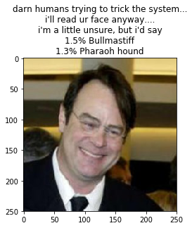

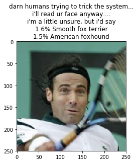

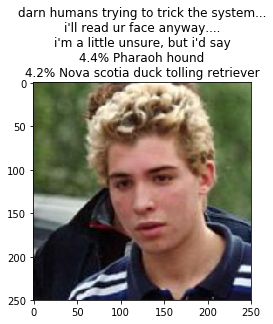

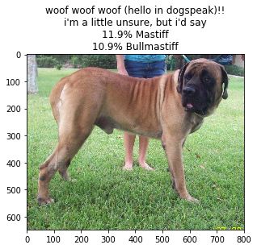

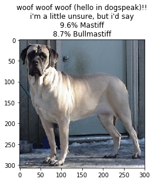

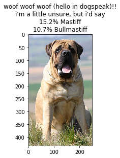

```python
for file in np.hstack((human_files[:3], dog_files[:3])):
    run_app(file, inception, model_transfer)
```

### Some extra examples

How well do we perform on **non-dog images**: do we catch them?

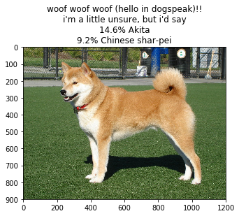

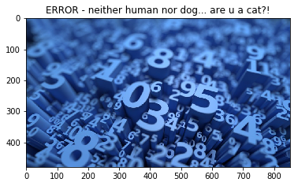

[figure not shown]

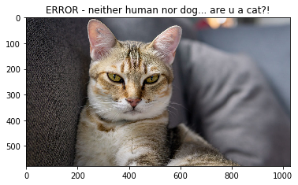

```python
extra_images = ['./images/Taka_Shiba.jpg',
                './images/random.jpg',
                './images/cat.jpg',
                './images/cat2.jpg',
               ]
for file in extra_images:
    run_app(file, inception, model_transfer)
```

Note that we got the first cat wrong -- we correctly detected that it was NOT a dog, but thought that it was a human. I proceeded to look at **where the CV algo thought it was a human**. In the process, I realized that it was detecting a very **small area** near the cat's ear as a face, possibly because the **input image was large (>1000px)** and provided enough fidelity. Instead, when I resized the image, the human face disappeared.

```
Number of faces detected: 1
```

[figure not shown]

```python
# Face detected
show_face('./images/cat.jpg')
```

```
Number of faces detected: 0
```

[figure not shown]

```python
# No face detected after scaling down 50%
show_face('./images/cat.jpg', scale=0.5)
```

### Non-conventional dog images

[figure not shown]

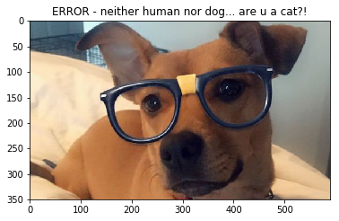

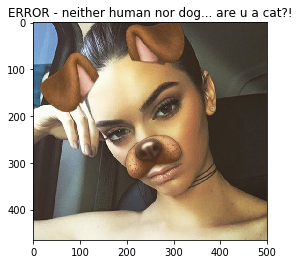

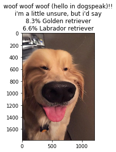

[figure not shown]

```python
others = ['./images/snapdog0.jpg',
          './images/snapdog1.jpg',
          './images/snapdog2.jpg',
          './images/stretchdog.jpg',
          './images/dug_up.jpg'
         ]
for file in others:
    run_app(file, inception, model_transfer)
```